# Advent of Code 2022

Author

Kasia Kedzierska

Published

December 19, 2022

## Intro

This notebook contains the solutions to the [Advent of Code 2022 problems](https://adventofcode.com/2022). The repository with source code for this notebook (and solutions for AoC 2020) can be found [here](https://github.com/kzkedzierska/aoc).

From [Wikipedia](https://en.wikipedia.org/wiki/Advent_of_Code): Advent of Code is an annual set of Christmas-themed computer programming challenges that follow an Advent calendar. It has been running since 2015.

### Summary

I got busy and had to skip a week of answers - hence why not all problems are solved yet.

Week 1

Week 2

Week 3

Week 4

| Day | Part 1 | Part 2 |
| --- | --- | --- |
| 1 | ⭐ | ⭐ |
| 2 | ⭐ | ⭐ |
| 3 | ⭐ | ⭐ |
| 4 | ⭐ | ⭐ |
| 5 | ⭐ | ⭐ |
| 6 | ⭐ | ⭐ |
| 7 | ⭐ | ⭐ |

| Day | Part 1 | Part 2 |
| --- | --- | --- |
| 8 | ⭐ | ⭐ |
| 9 |  |  |
| 10 | ⭐ | ⭐ |
| 11 | ⭐ | ⭐ |
| 12 |  |  |
| 13 |  |  |
| 14 |  |  |

| Day | Part 1 | Part 2 |
| --- | --- | --- |
| 18 | ⭐ |  |
| 15 |  |  |
| 16 |  |  |
| 17 |  |  |
| 19 |  |  |
| 20 |  |  |
| 21 |  |  |

| Day | Part 1 | Part 2 |
| --- | --- | --- |
| 22 |  |  |
| 23 |  |  |
| 24 |  |  |
| 25 |  |  |

## Day 1: Calorie Counting

### Part one ⭐

The jungle must be too overgrown and difficult to navigate in vehicles or access from the air; the Elves’ expedition traditionally goes on foot. As your boats approach land, the Elves begin taking inventory of their supplies. One important consideration is food - in particular, the number of Calories each Elf is carrying (your puzzle input).

The Elves take turns writing down the number of Calories contained by the various meals, snacks, rations, etc. that they’ve brought with them, one item per line. Each Elf separates their own inventory from the previous Elf’s inventory (if any) by a blank line.

For example, suppose the Elves finish writing their items’ Calories and end up with the following list:

```
1000
2000
3000

4000

5000
6000

7000
8000
9000

10000
```

This list represents the Calories of the food carried by five Elves:

- The first Elf is carrying food with `1000`, `2000`, and `3000` Calories, a total of `6000` Calories.
- The second Elf is carrying one food item with `4000` Calories.
- The third Elf is carrying food with `5000` and `6000` Calories, a total of `11000` Calories.
- The fourth Elf is carrying food with `7000`, `8000`, and `9000` Calories, a total of `24000` Calories. The fifth Elf is carrying one food item with `10000` Calories. In case the Elves get hungry and need extra snacks, they need to know which Elf to ask: they’d like to know how many Calories are being carried by the Elf carrying the **most** Calories. In the example above, this is `24000` (carried by the fourth Elf).

Find the Elf carrying the most Calories. **How many total Calories is that Elf carrying?**

```python
def max_calories_snacks(input_file):
  snacks = []
  i = 0
  start = True
  with open(input_file, "r+") as f:
    lines = [line.rstrip() for line in f]
    for line in lines:
      if line == "":
        i += 1
      else:
        if len(snacks) > i:
          snacks[i].append(int(line))
        else:
          snacks.append([int(line)])

  sum_snacks = [sum(snacks_) for snacks_ in snacks]
  max_calories = max(sum_snacks)
  return max_calories

# passing test?
max_calories_snacks("inputs/01_test_case.txt") == 24000
```

```
True
```

```python
max_calories_snacks("inputs/01_input.txt")
```

```
69528
```

**Outcome:** That’s the right answer! You are **one gold star** ⭐ closer to collecting enough star fruit.

### Part two ⭐

By the time you calculate the answer to the Elves’ question, they’ve already realized that the Elf carrying the most Calories of food might eventually **run out of snacks**.

To avoid this unacceptable situation, the Elves would instead like to know the total Calories carried by the top three Elves carrying the most Calories. That way, even if one of those Elves runs out of snacks, they still have two backups.

In the example above, the top three Elves are the fourth Elf (with `24000` Calories), then the third Elf (with `11000` Calories), then the fifth Elf (with `10000` Calories). The sum of the Calories carried by these three elves is `45000`.

Find the top three Elves carrying the most Calories. How many Calories are those Elves carrying in total?

```python
def nmax_calories_snacks(input_file, n):
  snacks = []
  i = 0
  start = True
  with open(input_file, "r+") as f:
    lines = [line.rstrip() for line in f]
    for line in lines:
      if line == "":
        i += 1
      else:
        if len(snacks) > i:
          snacks[i].append(int(line))
        else:
          snacks.append([int(line)])

  sum_snacks = [sum(snacks_) for snacks_ in snacks]
  sum_snacks.sort(reverse=True)
  return sum(sum_snacks[:n])

# passing test?
nmax_calories_snacks("inputs/01_test_case.txt", 2) == 35000
```

```
True
```

```python
nmax_calories_snacks("inputs/01_input.txt", 3)
```

```
206152
```

**Outcome:** That’s the right answer! You are **one gold star** ⭐ closer to collecting enough star fruit.

## Day 2: Rock Paper Scissors

### Part one ⭐

The Elves begin to set up camp on the beach. To decide whose tent gets to be closest to the snack storage, a giant **Rock Paper Scissors** tournament is already in progress.

Rock Paper Scissors is a game between two players. Each game contains many rounds; in each round, the players each simultaneously choose one of Rock, Paper, or Scissors using a hand shape. Then, a winner for that round is selected: Rock defeats Scissors, Scissors defeats Paper, and Paper defeats Rock. If both players choose the same shape, the round instead ends in a draw.

Appreciative of your help yesterday, one Elf gives you an **encrypted strategy guide** (your puzzle input) that they say will be sure to help you win. “The first column is what your opponent is going to play: `A` for Rock, `B` for Paper, and `C` for Scissors. The second column–” Suddenly, the Elf is called away to help with someone’s tent.

The second column, you reason, must be what you should play in response: `X` for Rock, `Y` for Paper, and `Z` for Scissors. Winning every time would be suspicious, so the responses must have been carefully chosen.

The winner of the whole tournament is the player with the highest score. Your **total score** is the sum of your scores for each round. The score for a single round is the score for the **shape you selected** (1 for Rock, 2 for Paper, and 3 for Scissors) plus the score for the outcome of the round (0 if you lost, 3 if the round was a draw, and 6 if you won).

Since you can’t be sure if the Elf is trying to help you or trick you, you should calculate the score you would get if you were to follow the strategy guide.

For example, suppose you were given the following strategy guide:

```
A Y
B X
C Z
```

This strategy guide predicts and recommends the following:

- In the first round, your opponent will choose Rock (`A`), and you should choose Paper (`Y`). This ends in a win for you with a score of 8 (2 because you chose Paper + 6 because you won).
- In the second round, your opponent will choose Paper (`B`), and you should choose Rock (`X`). This ends in a loss for you with a score of 1 (1 + 0).
- The third round is a draw with both players choosing Scissors, giving you a score of 3 + 3 = 6.

In this example, if you were to follow the strategy guide, you would get a total score of **15** (8 + 1 + 6).

**What would your total score be if everything goes exactly according to your strategy guide?**

```python
def rps(input_file):
  outcomes = {"A": {"X": 3+1, "Y": 6+2, "Z": 0+3},
              "B": {"X": 0+1, "Y": 3+2, "Z": 6+3},
              "C": {"X": 6+1, "Y": 0+2, "Z": 3+3}}
  scores = []
  with open(input_file, "r+") as f:
    for line in f.readlines():
      game = line.rstrip().split(" ")
      scores.append(outcomes[game[0]][game[1]])
  return sum(scores)

rps("inputs/02_test_case.txt") == 15
```

```
True
```

```python
rps("inputs/02_input.txt")
```

```
14264
```

**Outcome:** That’s the right answer! You are **one gold star** ⭐ closer to collecting enough star fruit.

### Part two ⭐

The Elf finishes helping with the tent and sneaks back over to you. “Anyway, the second column says how the round needs to end: `X` means you need to lose, `Y` means you need to end the round in a draw, and `Z` means you need to win. Good luck!”

The total score is still calculated in the same way, but now you need to figure out what shape to choose so the round ends as indicated. The example above now goes like this:

- In the first round, your opponent will choose Rock (`A`), and you need the round to end in a draw (`Y`), so you also choose Rock. This gives you a score of 1 + 3 = **4**.
- In the second round, your opponent will choose Paper (`B`), and you choose Rock so you lose (`X`) with a score of 1 + 0 = **1**.
- In the third round, you will defeat your opponent’s Scissors with Rock for a score of 1 + 6 = **7**.

Now that you’re correctly decrypting the ultra top secret strategy guide, you would get a total score of **12**.

Following the Elf’s instructions for the second column, **what would your total score be if everything goes exactly according to your strategy guide?**

```python
def rps_modified(input_file):
  outcomes = {"A": {"X": 0+3, # lose (0) => scissors (3)
                    "Y": 3+1, # draw (3) => rock (1)
                    "Z": 6+2}, # win (6) => paper (2)
              "B": {"X": 0+1, # lose => rock (1)
                    "Y": 3+2, # draw => paper (2)
                    "Z": 6+3}, # win => scissors (3)
              "C": {"X": 0+2, # lose => paper (2)
                    "Y": 3+3, # draw  => scissors (3)
                    "Z": 6+1}} # win => rock (1)
  scores = []
  with open(input_file, "r+") as f:
    for line in f.readlines():
      game = line.rstrip().split(" ")
      scores.append(outcomes[game[0]][game[1]])
  return sum(scores)

# does it pass test case?
rps_modified("inputs/02_test_case.txt") == 12
```

```
True
```

```python
rps_modified("inputs/02_input.txt")
```

```
12382
```

**Outcome:** That’s the right answer! You are **one gold star** ⭐ closer to collecting enough star fruit.

## Day 3: Rucksack Reorganization

### Part one ⭐

One Elf has the important job of loading all of the rucksacks with supplies for the jungle journey. Unfortunately, that Elf didn’t quite follow the packing instructions, and so a few items now need to be rearranged.

Each rucksack has two large **compartments**. All items of a given type are meant to go into exactly one of the two compartments. The Elf that did the packing failed to follow this rule for exactly one item type per rucksack.

The Elves have made a list of all of the items currently in each rucksack (your puzzle input), but they need your help finding the errors. Every item type is identified by a single lowercase or uppercase letter (that is, a and A refer to different types of items).

The list of items for each rucksack is given as characters all on a single line. A given rucksack always has the same number of items in each of its two compartments, so the first half of the characters represent items in the first compartment, while the second half of the characters represent items in the second compartment.

For example, suppose you have the following list of contents from six rucksacks:

```
vJrwpWtwJgWrhcsFMMfFFhFp
jqHRNqRjqzjGDLGLrsFMfFZSrLrFZsSL
PmmdzqPrVvPwwTWBwg
wMqvLMZHhHMvwLHjbvcjnnSBnvTQFn
ttgJtRGJQctTZtZT
CrZsJsPPZsGzwwsLwLmpwMDw
```

- The first rucksack contains the items `vJrwpWtwJgWrhcsFMMfFFhFp`, which means its first compartment contains the items `vJrwpWtwJgWr`, while the second compartment contains the items `hcsFMMfFFhFp`. The only item type that appears in both compartments is lowercase `p`.
- The second rucksack’s compartments contain `jqHRNqRjqzjGDLGL` and `rsFMfFZSrLrFZsSL`. The only item type that appears in both compartments is uppercase `L`.
- The third rucksack’s compartments contain `PmmdzqPrV` and `vPwwTWBwg`; the only common item type is uppercase `P`.
- The fourth rucksack’s compartments only share item type `v`.
- The fifth rucksack’s compartments only share item type `t`.
- The sixth rucksack’s compartments only share item type `s`.

To help prioritize item rearrangement, every item type can be converted to a **priority**:

- Lowercase item types `a` through `z` have priorities 1 through 26.
- Uppercase item types `A` through `Z` have priorities 27 through 52.

In the above example, the priority of the item type that appears in both compartments of each rucksack is 16 (`p`), 38 (`L`), 42 (`P`), 22 (`v`), 20 (`t`), and 19 (`s`); the sum of these is **157**.

Find the item type that appears in both compartments of each rucksack. **What is the sum of the priorities of those item types?**

```python
def rucksuck(input_file):
  prior_sum = 0
  with open(input_file, "r+") as f:
    for line in f.readlines():
      inside = [el for el in line.rstrip()]
      # get unique items of each compartment
      comp1 = set(inside[:len(inside)//2])
      comp2 = set(inside[len(inside)//2:])
      # get the element that is common
      el = list(comp1.intersection(comp2))[0]
      if el == el.upper():
        p = ord(el) - 65 + 27
      else:
        p = ord(el) - 97 + 1
      # add the priority to the sum
      prior_sum += p
  return prior_sum

rucksuck("inputs/03_test_case.txt") == 157
```

```
True
```

```python
rucksuck("inputs/03_input.txt")
```

```
8018
```

**Outcome:** That’s the right answer! You are **one gold star** ⭐ closer to collecting enough star fruit.

### Part two ⭐

As you finish identifying the misplaced items, the Elves come to you with another issue.

For safety, the Elves are divided into groups of three. Every Elf carries a badge that identifies their group. For efficiency, within each group of three Elves, the badge is the **only item type carried by all three Elves**. That is, if a group’s badge is item type `B`, then all three Elves will have item type `B` somewhere in their rucksack, and at most two of the Elves will be carrying any other item type.

The problem is that someone forgot to put this year’s updated authenticity sticker on the badges. All of the badges need to be pulled out of the rucksacks so the new authenticity stickers can be attached.

Additionally, nobody wrote down which item type corresponds to each group’s badges. The only way to tell which item type is the right one is by finding the one item type that is **common between all three Elves** in each group.

Every set of three lines in your list corresponds to a single group, but each group can have a different badge item type. So, in the above example, the first group’s rucksacks are the first three lines:

```
vJrwpWtwJgWrhcsFMMfFFhFp
jqHRNqRjqzjGDLGLrsFMfFZSrLrFZsSL
PmmdzqPrVvPwwTWBwg
```

And the second group’s rucksacks are the next three lines:

```
wMqvLMZHhHMvwLHjbvcjnnSBnvTQFn
ttgJtRGJQctTZtZT
CrZsJsPPZsGzwwsLwLmpwMDw
```

In the first group, the only item type that appears in all three rucksacks is lowercase `r`; this must be their badges. In the second group, their badge item type must be `Z`.

Priorities for these items must still be found to organize the sticker attachment efforts: here, they are 18 (`r`) for the first group and 52 (`Z`) for the second group. The sum of these is **70**.

Find the item type that corresponds to the badges of each three-Elf group. **What is the sum of the priorities of those item types?**

```python
def rucksuck_badges(input_file):
  cc = set()
  elves = 0
  prior_sum = 0
  with open(input_file, "r+") as f:
    for line in f.readlines():
      carryon = set([el for el in line.rstrip()])

      elves += 1

      cc = carryon if elves % 3 == 1 else cc.intersection(carryon)

      if (elves % 3 == 0):

        badge = list(cc)[0]
        cc = set()

        if badge == badge.upper():
          p = ord(badge) - 65 + 27

        else:
          p = ord(badge) - 97 + 1

        # add the priority to the sum
        prior_sum += p

  return prior_sum

# does it pass test?
rucksuck_badges("inputs/03_test_case.txt") == 70
```

```
True
```

```python
rucksuck_badges("inputs/03_input.txt")
```

```
2518
```

**Outcome:** That’s the right answer! You are **one gold star** ⭐ closer to collecting enough star fruit.

## Day 4: Camp Cleanup

### Part one ⭐

Space needs to be cleared before the last supplies can be unloaded from the ships, and so several Elves have been assigned the job of cleaning up sections of the camp. Every section has a unique **ID number**, and each Elf is assigned a range of section IDs.

However, as some of the Elves compare their section assignments with each other, they’ve noticed that many of the assignments **overlap**. To try to quickly find overlaps and reduce duplicated effort, the Elves pair up and make a **big list of the section assignments for each pair** (your puzzle input).

For example, consider the following list of section assignment pairs:

```
2-4,6-8
2-3,4-5
5-7,7-9
2-8,3-7
6-6,4-6
2-6,4-8
```

For the first few pairs, this list means:

- Within the first pair of Elves, the first Elf was assigned sections `2-4` (sections `2`, `3`, and `4`), while the second Elf was assigned sections `6-8` (sections `6`, `7`, `8`).
- The Elves in the second pair were each assigned two sections.
- The Elves in the third pair were each assigned three sections: one got sections `5`, `6`, and `7`, while the other also got `7`, plus `8` and `9`.

This example list uses single-digit section IDs to make it easier to draw; your actual list might contain larger numbers. Visually, these pairs of section assignments look like this:

```
.234.....  2-4
.....678.  6-8

.23......  2-3
...45....  4-5

....567..  5-7
......789  7-9

.2345678.  2-8
..34567..  3-7

.....6...  6-6
...456...  4-6

.23456...  2-6
...45678.  4-8
```

Some of the pairs have noticed that one of their assignments **fully contains the other**. For example, `2-8` fully contains `3-7`, and `6-6` is fully contained by `4-6`. In pairs where one assignment fully contains the other, one Elf in the pair would be exclusively cleaning sections their partner will already be cleaning, so these seem like the most in need of reconsideration. In this example, there are 2 such pairs.

**In how many assignment pairs does one range fully contain the other?**

```python
# Define wrapper for checking test case
def test_case(cmd, result):
  assert cmd == result, f"Should be {result}, is {cmd}"

def compare_ranges(range1, range2):
  r1 = [int(el) for el in range1.split("-")]
  r2 = [int(el) for el in range2.split("-")]

  if ((r1[0] >= r2[0]) & (r1[1] <= r2[1])):
    return True

  elif ((r2[0] >= r1[0]) & (r2[1] <= r1[1])):
    return True

  else:
    return False

test_case(compare_ranges("1-3", "2-5"), False)
test_case(compare_ranges("1-6", "2-5"), True)

def camp_cleanup(input_file):
  with open(input_file, "r+") as f:
    ranges = [line.split(",") for line in f.readlines()]

    fully_contain = [compare_ranges(r[0], r[1]) for r in ranges]

    return sum(fully_contain)

test_case(camp_cleanup("inputs/04_test_case.txt"), 2)
```

```python
camp_cleanup("inputs/04_input.txt")
```

```
483
```

**Outcome:** That’s the right answer! You are **one gold star** ⭐ closer to collecting enough star fruit.

### Part two ⭐

It seems like there is still quite a bit of duplicate work planned. Instead, the Elves would like to know the number of pairs that **overlap at all**.

In the above example, the first two pairs (`2-4`,`6-8` and `2-3`,`4-5`) don’t overlap, while the remaining four pairs (`5-7`,`7-9`, `2-8`,`3-7`, `6-6`,`4-6`, and `2-6`,`4-8`) do overlap:

- `5-7`,`7-9` overlaps in a single section, `7`.
- `2-8`,`3-7` overlaps all of the sections `3` through `7`.
- `6-6`,`4-6` overlaps in a single section, `6`.
- `2-6`,`4-8` overlaps in sections `4`, `5`, and `6`.

So, in this example, the number of overlapping assignment pairs is **4**.

**In how many assignment pairs do the ranges overlap?**

```python
# this solution also works for part 1
def compare_ranges_p2(range1, range2, fully=True):
  r1 = [int(el) for el in range1.split("-")]
  r1 = set(range(r1[0], r1[1] + 1))

  r2 = [int(el) for el in range2.split("-")]
  r2 = set(range(r2[0], r2[1] + 1))

  # get the intersection
  inter = r1.intersection(r2)

  # if interested in fully only, check if intersection
  # is the size of smaller set
  if ((fully) & (len(inter) == min(len(r1), len(r2)))):
    return True

  # if any overlap, check if intersection non empty
  if ((not fully) & (len(inter) > 0)):
    return True

  # all other case mean no overlap
  return False

# check if part 1 would be good
test_case(compare_ranges_p2("1-3", "2-5"), False)
# check the test cases for not fully overlapping
test_case(compare_ranges_p2("1-3", "2-5", fully=False), True)
test_case(compare_ranges_p2("1-3", "4-5", fully=False), False)


def camp_cleanup_p2(input_file, fully=True):
  with open(input_file, "r+") as f:
    ranges = [line.split(",") for line in f.readlines()]

    overlaps = [compare_ranges_p2(r[0], r[1], fully) for r in ranges]

    return sum(overlaps)

# check if part 1 would be good
test_case(camp_cleanup_p2("inputs/04_test_case.txt"), 2)
# check test case
test_case(camp_cleanup_p2("inputs/04_test_case.txt", fully=False), 4)
```

```python
camp_cleanup_p2("inputs/04_input.txt", fully=False)
```

```
874
```

**Outcome:** That’s the right answer! You are **one gold star** ⭐ closer to collecting enough star fruit.

### Visualisation

First, I will read in the data and process it.

```r
camp_cleanup_input_df <-
  # read in input
  readr::read_csv("inputs/04_input.txt",
                col_names = c("elf1", "elf2"),
                col_types = "c") %>%
  # number pairs
  dplyr::mutate(pair = as.character(1:n())) %>%
  # make longer to look like this:
  # pair  elf     range
  # 1     "elf1"  "1-3"
  # 1     "elf2"  "3-5"
  tidyr::pivot_longer(names_to = "elf", values_to = "range",
                      dplyr::starts_with("elf")) %>%
  # extract start & end range to look like this:
  # pair  elf     range   range_start   range_end
  # 1     "elf1"  "1-3"   1             3
  # 1     "elf2"  "3-5"   3             5
  tidyr::separate(range, into = c("range_start", "range_end"),
                  sep = "-", convert = TRUE, remove = FALSE) %>%
  # list all assignments within range:
  # pair  elf     range   range_start   range_end   range_pos
  # 1     "elf1"  "1-3"   1             3           "1;2;3"
  # 1     "elf2"  "3-5"   3             5           "3;4;5"
  dplyr::rowwise() %>%
  dplyr::mutate(range_pos = paste(seq(range_start, range_end),
                                  collapse = ";")) %>%
  # replace elf range with both ranges:
  # pair  elf     range       range_start   range_end   range_pos
  # 1     "elf1"  "1-3,3-5"   1             3           "1;2;3"
  # 1     "elf2"  "1-3,3-5"   3             5           "3;4;5"
  dplyr::group_by(pair) %>%
  dplyr::mutate(range = paste(unique(range), collapse = ",")) %>%
  # separate rows:
  # pair  elf     range       range_start   range_end   range_pos
  # 1     "elf1"  "1-3,3-5"   1             3           1
  # 1     "elf1"  "1-3,3-5"   1             3           2
  # 1     "elf1"  "1-3,3-5"   1             3           3
  # 1     "elf2"  "1-3,3-5"   3             5           3
  # 1     "elf2"  "1-3,3-5"   3             5           4
  # 1     "elf2"  "1-3,3-5"   3             5           5
  tidyr::separate_rows(range_pos, sep = ";", convert = TRUE) %>%
  # make a note if both elves assigned same room:
  # pair  range       range_pos   elf
  # 1     "1-3,3-5"   1           "elf1"
  # 1     "1-3,3-5"   2           "elf1"
  # 1     "1-3,3-5"   3           "both"
  # 1     "1-3,3-5"   4           "elf2"
  # 1     "1-3,3-5"   5           "elf2"
  dplyr::group_by(pair, range, range_pos) %>%
  dplyr::mutate(elf = case_when(
    dplyr::n() == 1 ~ elf,
    TRUE ~ "both"
  ), .groups = "drop") %>%
  unique() %>%
  # label the pair as one of 3 cases
  # pair  range       range_pos   elf     overlap
  # 1     "1-3,3-5"   1           "elf1"  "Case 2: there is some overlap"
  # 2     "1-2,4-7"   4           "elf2"  "Case 3: no overlap"
  # 3     "4-5,2-6"   5           "both"  "Case 1: one fully contains the other"
  dplyr::group_by(pair) %>%
  dplyr::mutate(
    overlap = case_when(
      # when one contains the other, there is only "both" and one
      # of the elves
      length(unique(elf)) < 3 &
        "both" %in% unique(elf) ~ "Case 1: one fully contains the other",
      # when there is just some overlap - that's the second case
      any(elf == "both") ~ "Case 2: there is some overlap",
      # all other cases - no overlap
      TRUE ~ "Case 3: no overlap"),
    # make into factor for nice plotting
    overlap = factor(overlap,
                     levels = c("Case 1: one fully contains the other",
                                "Case 2: there is some overlap",
                                "Case 3: no overlap"))) %>%
  dplyr::ungroup()
```

```r
camp_cleanup_counted_df <-
  camp_cleanup_input_df %>%
  dplyr::select(pair, overlap) %>%
  unique() %>%
  dplyr::count(overlap)

n_pairs_with_full_overlap <-
  camp_cleanup_counted_df %>%
  dplyr::filter(overlap == "Case 1: one fully contains the other") %>%
  dplyr::pull(n)

n_pairs_with_overlap <-
  camp_cleanup_counted_df %>%
  dplyr::filter(overlap != "Case 3: no overlap") %>%
  dplyr::pull(n) %>%
  sum()

n_pairs_without_overlap <-
  camp_cleanup_counted_df %>%
  dplyr::filter(overlap == "Case 3: no overlap") %>%
  dplyr::pull(n) %>%
  sum()
```

After processing the data, I can check the answers:

```r
camp_cleanup_counted_df
```

```
# A tibble: 3 × 2
  overlap                                  n
  <fct>                                <int>
1 Case 1: one fully contains the other   483
2 Case 2: there is some overlap          391
3 Case 3: no overlap                     126
```

For part 1, the answer is 483 and for part 2: 874 (sum of *Case 1* and *Case 2*).

```r
library(ggplot2)
sysfonts::font_add_google("Permanent Marker")
showtext::showtext_auto()
theme_set(theme_minimal() +
            theme(panel.grid.minor = element_blank(),
                   panel.grid.major.y = element_line(linetype = "dotted", color = "black"),
                   panel.grid.major.x = element_blank(),
                   axis.ticks.x = element_line(), legend.position = "bottom",
                   text = element_text(family = "Permanent Marker", size = 16)))
```

Now, let’s see how do those cases look like if visualised. We have 3 cases - where assignment of one fully contains the other, where there is some overlap and when the assignments do not overlap.

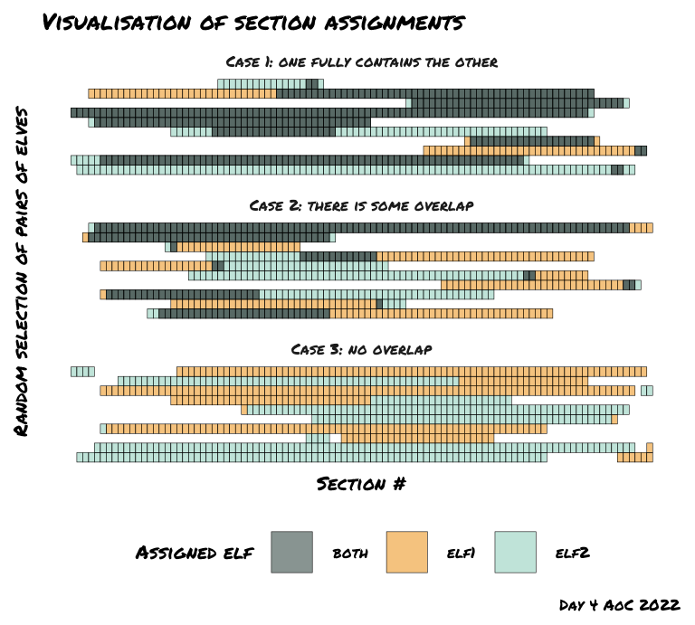

```r
camp_cleanup_input_df %>%
  dplyr::group_by(overlap) %>%
  dplyr::filter(pair %in% sample(unique(pair), 10)) %>%
  ggplot(aes(range_pos, pair, fill = elf)) +
  geom_tile(alpha = 0.6, color = "black") +
  facet_wrap(overlap~., scales = "free_y", ncol = 1) +
  scale_fill_manual(values = c("elf1" = "#EC9A29",
                               "elf2" = "#94D1BE",
                               "both" = "#3A4E48")) +
  theme(axis.ticks = element_blank(),
        axis.text = element_blank(),
        legend.position = "bottom",
        panel.grid.major.y = element_blank(),
        axis.ticks.x = element_blank()) +
  labs(x = "Section #",
       y = "Random selection of pairs of elves",
       title = "Visualisation of section assignments",
       fill = "Assigned elf",
       caption = "Day 4 AoC 2022")
```

What fraction of the assignments overlaps between the elves (as fraction of the bigger assignment)?

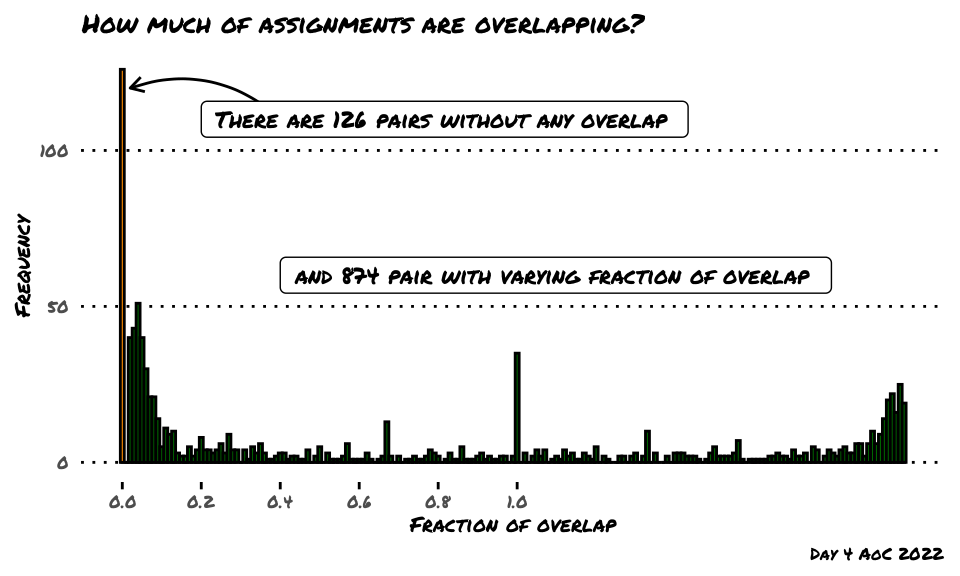

```r
fract_per_section_df <-
  camp_cleanup_input_df %>%
  dplyr::group_by(pair, range) %>%
  dplyr::mutate(max_range = max(range_pos) - min(range_pos) + 1) %>%
  dplyr::group_by(pair, max_range, overlap) %>%
  dplyr::summarise(count = sum(elf == "both"), .groups = "drop") %>%
  dplyr::mutate(fract_overlap = count / max_range)



fract_per_section_df %>%
  ggplot(aes(fract_overlap)) +
  geom_histogram(data = . %>% dplyr::filter(fract_overlap > 0),
                 binwidth = 0.01, fill = "darkgreen", color = "black") +
  geom_histogram(data = . %>% dplyr::filter(fract_overlap == 0),
                 binwidth = 0.01, fill = "darkorange", color = "black") +
  annotate("curve",
           x = 0.4, xend = 0.02,
           y = 110, yend = 120,
           curvature = .3,
           arrow = arrow(length = unit(2, "mm"))) +
  annotate(geom = "label",
           x = 0.2, y = 110,
           label = glue::glue("There are {n_pairs_without_overlap} pairs without any overlap  "),
           hjust = "left", family = "Permanent Marker", size = 6) +
  annotate(geom = "label",
           x = 0.4, y = 60,
           label = glue::glue("and {n_pairs_with_overlap} pair with varying fraction of overlap  "),
           hjust = "left", family = "Permanent Marker", size = 6) +
  labs(title = "How much of assignments are overlapping?",
       caption = "Day 4 AoC 2022",
       x = "Fraction of overlap",
       y = "Frequency") +
  scale_x_continuous(breaks = seq(0, 1, 0.2))
```

How many elves were assigned per each section?

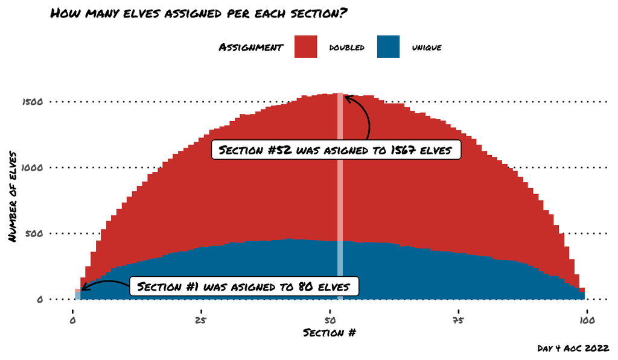

```r
per_pos_counts_df <-
  camp_cleanup_input_df %>%
  dplyr::mutate(elf = stringr::str_remove(elf, "[1-2]")) %>%
  dplyr::count(range_pos, elf) %>%
  dplyr::ungroup() %>%
  dplyr::mutate(n = case_when(
    elf == "both" ~ as.integer(2*n),
    TRUE ~ n)) %>%
  dplyr::group_by(range_pos) %>%
  dplyr::mutate(sum_cleaned = sum(n)) %>%
  dplyr::ungroup() %>%
  dplyr::mutate(most_cleaned = sum_cleaned == max(sum_cleaned),
                least_cleaned = sum_cleaned == min(sum_cleaned))

min_pos <-
  per_pos_counts_df %>% filter(least_cleaned) %>% pull(range_pos)

max_pos <-
  per_pos_counts_df %>% filter(most_cleaned) %>% pull(range_pos)

min_n <-
  per_pos_counts_df %>% filter(least_cleaned) %>% pull(sum_cleaned)

max_n <-
  per_pos_counts_df %>% filter(most_cleaned) %>% pull(sum_cleaned)

per_pos_counts_df %>%
  ggplot(aes(range_pos, n)) +
  geom_bar(aes(fill = elf), stat = "identity", width = 1, color = NA) +
  geom_bar(data = . %>% dplyr::filter(most_cleaned | least_cleaned),
           aes(group = elf), stat = "identity", width = 1, color = NA,
           fill = "white", alpha = .5) +
  annotate("curve",
           x = max_pos + 5, xend = max_pos + 1,
           y = max_n - 370, yend = max_n - 30,
           arrow = arrow(length = unit(2, "mm"))) +
  annotate(geom = "label",
           x = max_pos - 25, y = max_n - 430,
           label = glue::glue("Section #{max_pos} was asigned to {max_n} elves  "),
           hjust = "left", family = "Permanent Marker", size = 6) +
  annotate("curve",
           x = min_pos + 10, xend = min_pos + 0.9,
           y = min_n + 20, yend = min_n*0.9,
           curvature = .3, arrow = arrow(length = unit(2, "mm"))) +
  annotate(geom = "label", x = min_pos + 10 + 0.1, y = min_n + 20,
           label = glue::glue("Section #{min_pos} was asigned to {min_n} elves  "),
           hjust = "left", family = "Permanent Marker", size = 6) +
  ggthemes::scale_fill_wsj(labels = c("doubled", "unique")) +
  labs(title = "How many elves assigned per each section?",
       caption = "Day 4 AoC 2022",
       x = "Section #", y = "Number of elves",
       fill = "Assignment") +
  theme(legend.position = "top")
```

How many sections were assigned per elf? Size of assignments tends to be bigger in case of one assignment containing other one.

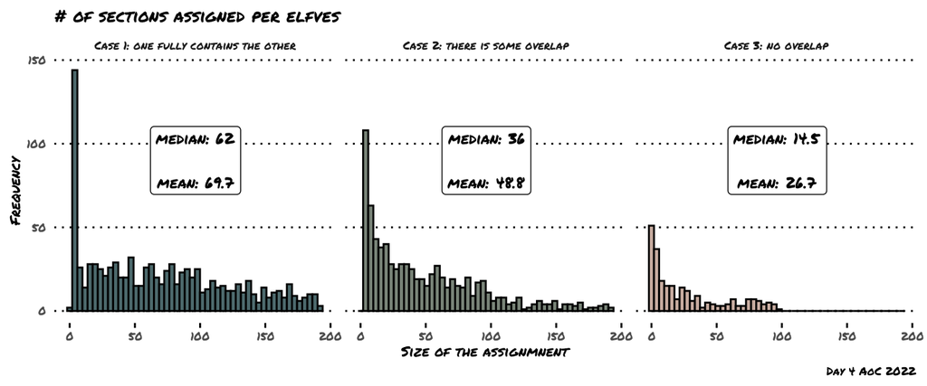

```r
sections_per_elf_df <-
  camp_cleanup_input_df %>%
  dplyr::mutate(elf = case_when(
    elf == "both" ~ "elf1;elf2",
    TRUE ~ elf
  )) %>%
  tidyr::separate_rows(elf, sep = ";") %>%
  dplyr::count(pair, overlap, elf)

sections_per_elf_df %>%
  dplyr::group_by(overlap) %>%
  dplyr::mutate(median = round(median(n), 1),
                mean = round(mean(n), 1),
                temp_fill = stringr::str_extract(overlap, "Case [0-9]+")) %>%
  ggplot(aes(n)) +
  geom_histogram(color = "black", aes(fill = temp_fill), bins = 50) +
  geom_label(data = . %>% dplyr::select(overlap, median, mean) %>% unique(),
             size = 6,
             aes(x = max(sections_per_elf_df$n)/2, y = 90,
                 label = glue::glue("median: {median}\nmean: {mean}")),
             family = "Permanent Marker") +
  facet_wrap(~overlap) +
  scale_fill_manual(values = c("Case 1" = "#4D6A6D",
                               "Case 2" = "#798478",
                               "Case 3" = "#C9ADA1")) +
  theme(legend.position = "none") +
  labs(title = "# of sections assigned per elfves",
       y = "Frequency",
       x = "Size of the assignmnent",
       caption = "Day 4 AoC 2022")
```

There are a lot of pairs with same length of assignments in the overlap cases.

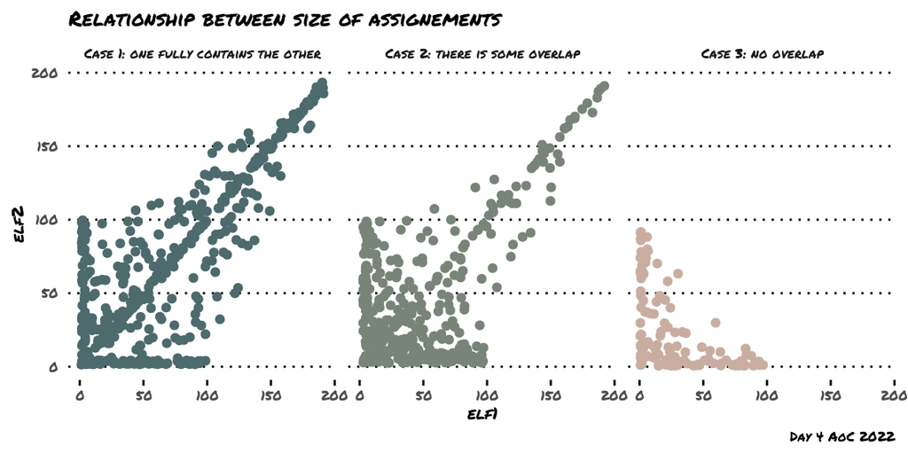

```r
sections_per_elf_df %>%
  dplyr::group_by(overlap) %>%
  dplyr::mutate(median = round(median(n), 1),
                mean = round(mean(n), 1),
                temp_fill = stringr::str_extract(overlap, "Case [0-9]+")) %>%
  tidyr::pivot_wider(names_from = "elf", values_from = "n") %>%
  ggplot(aes(elf1, elf2)) +
  geom_jitter(aes(color = temp_fill)) +
  facet_wrap(~overlap) +
  scale_color_manual(values = c("Case 1" = "#4D6A6D",
                                "Case 2" = "#798478",
                                "Case 3" = "#C9ADA1")) +
  theme(legend.position = "none") +
  labs(caption = "Day 4 AoC 2022",
       title = "Relationship between size of assignements")
```

## Day 5: Supply Stacks

### Part one ⭐

The expedition can depart as soon as the final supplies have been unloaded from the ships. Supplies are stored in stacks of marked **crates**, but because the needed supplies are buried under many other crates, the crates need to be rearranged.

The ship has a **giant cargo crane** capable of moving crates between stacks. To ensure none of the crates get crushed or fall over, the crane operator will rearrange them in a series of carefully-planned steps. After the crates are rearranged, the desired crates will be at the top of each stack.

The Elves don’t want to interrupt the crane operator during this delicate procedure, but they forgot to ask her **which** crate will end up where, and they want to be ready to unload them as soon as possible so they can embark.

They do, however, have a drawing of the starting stacks of crates and the rearrangement procedure (your puzzle input). For example:

```
    [D]
[N] [C]
[Z] [M] [P]
 1   2   3

move 1 from 2 to 1
move 3 from 1 to 3
move 2 from 2 to 1
move 1 from 1 to 2
```

In this example, there are three stacks of crates. Stack 1 contains two crates: crate `Z` is on the bottom, and crate `N` is on top. Stack 2 contains three crates; from bottom to top, they are crates `M`, `C`, and `D`. Finally, stack 3 contains a single crate, `P`.

Then, the rearrangement procedure is given. In each step of the procedure, a quantity of crates is moved from one stack to a different stack. In the first step of the above rearrangement procedure, one crate is moved from stack 2 to stack 1, resulting in this configuration:

```
[D]
[N] [C]
[Z] [M] [P]
 1   2   3
```

In the second step, three crates are moved from stack 1 to stack 3. Crates are moved **one at a time**, so the first crate to be moved (`D`) ends up below the second and third crates:

```
        [Z]
        [N]
    [C] [D]
    [M] [P]
 1   2   3
```

Then, both crates are moved from stack 2 to stack 1. Again, because crates are moved **one at a time**, crate `C` ends up below crate `M`:

```
        [Z]
        [N]
[M]     [D]
[C]     [P]
 1   2   3
```

Finally, one crate is moved from stack 1 to stack 2:

```
        [Z]
        [N]
        [D]
[C] [M] [P]
 1   2   3
```

The Elves just need to know **which crate will end up on top of each stack**; in this example, the top crates are `C` in stack 1, `M` in stack 2, and `Z` in stack 3, so you should combine these together and give the Elves the message `CMZ`.

**After the rearrangement procedure completes, what crate ends up on top of each stack?**

First, I need to deal with input. I will sepatate the stacks and instructions into two files. I will also clean up stacks to ease reading it in, from this:

```
    [D]
[N] [C]
[Z] [M] [P]
 1   2   3
```

to this:

```
0D0
NC0
ZMP
123
```

Here `0` is an empty space, all spaces are removed such us that each space is represented by crate `A`-`Z` or `0`. Crates are numbered in the last line.

```bash
input_file=$1
# create the stacks input
grep -v ^move ${input_file} |
  # remove empty lines
  awk 'NF' |
    # treat all 4 spaces as empty position in stacks
    sed 's/ {4}/0/g' |
      # remove all spaces & [], each character should be stack
      sed 's/ //g;s/\[//g; s/\]//g' > ${input_file/.txt/_stacks.txt}

# create instructions input
grep ^move ${input_file} > ${input_file/.txt/_inst.txt}
```

I put the code in the script and run if from Python.

```python
def process_input(input_file):
  from subprocess import call, DEVNULL, STDOUT
  call("./helper_scripts/05_process_inputs.sh " + input_file,
       shell=True, stdout=DEVNULL, stderr=STDOUT)

process_input("inputs/05_test_case.txt")
```

Then, I process stacks input and create the stacks list - first element is the top of each stack.

```python
def read_input(input_file):
  levels = []
  with open(input_file, "r+") as f:
    lines = f.readlines()
    for line in lines:
      if line[0] != '1':
        levels.append([el for el in line.strip()])

  stacks = [[m[i] for m in levels if m[i] != '0'] for i in range(len(levels[0]))]
  return stacks

stacks = read_input("inputs/05_test_case_stacks.txt")
stacks
```

```
[['N', 'Z'], ['D', 'C', 'M'], ['P']]
```

Now, define logic to move crane, as per description the crane moves one crate at a time.

```python
def move_crane(input_instuctions, input_stacks):
  stacks = input_stacks.copy()
  with open(input_instuctions, "r+") as f:
    instructions = f.readlines()
    for inst in instructions:
      inst_l = inst.strip().split(" ")
      inst_l = [int(el) for el in inst_l[1::2]]
      how_many = inst_l[0]
      stack_from = stacks[inst_l[1]-1]
      stack_to = stacks[inst_l[2]-1]
      # print(f"Move {how_many} from {stack_from} to {stack_to}")
      for i in range(how_many):
        crate = stack_from[::-1].pop()
        stack_to.insert(0, crate)
        stack_from = stack_from[1:]

      stacks[inst_l[1]-1] = stack_from
      stacks[inst_l[2]-1] = stack_to

  return "".join([s[0] for s in stacks])

move_crane("inputs/05_test_case_inst.txt", stacks)
```

```
'CMZ'
```

And finally, create a function to run them all

```python
def day5_part1(input_file):
  # make sure the inputs are processed
  process_input(input_file)
  # read in the stacks
  stacks = read_input(input_file.replace(".txt", "_stacks.txt"))
  # move the crane
  out_str = move_crane(input_file.replace(".txt", "_inst.txt"), stacks)

  return out_str

# Define wrapper for checking test case
def test_case(cmd, result):
  assert cmd == result, f"Should be {result}, is {cmd}"

test_case(day5_part1("inputs/05_test_case.txt"), "CMZ")
# added after discovering bug in bash script
test_case(day5_part1("inputs/05_test_case_alt.txt"), "ZMN")
```

Check the answer

```python
day5_part1("inputs/05_input.txt")
```

```
'ZRLJGSCTR'
```

**Outcome:** That’s the right answer! You are **one gold star** ⭐ closer to collecting enough star fruit.

### Part two ⭐

As you watch the crane operator expertly rearrange the crates, you notice the process isn’t following your prediction.

Some mud was covering the writing on the side of the crane, and you quickly wipe it away. The crane isn’t a CrateMover 9000 - it’s a **CrateMover 9001**.

The CrateMover 9001 is notable for many new and exciting features: air conditioning, leather seats, an extra cup holder, and **the ability to pick up and move multiple crates at once**.

Again considering the example above, the crates begin in the same configuration:

```
    [D]
[N] [C]
[Z] [M] [P]
 1   2   3
```

Moving a single crate from stack 2 to stack 1 behaves the same as before:

```
[D]
[N] [C]
[Z] [M] [P]
 1   2   3
```

However, the action of moving three crates from stack 1 to stack 3 means that those three moved crates **stay in the same order**, resulting in this new configuration:

```
        [D]
        [N]
    [C] [Z]
    [M] [P]
 1   2   3
```

Next, as both crates are moved from stack 2 to stack 1, they **retain their order** as well:

```
        [D]
        [N]
[C]     [Z]
[M]     [P]
 1   2   3
```

Finally, a single crate is still moved from stack 1 to stack 2, but now it’s crate `C` that gets moved:

```
        [D]
        [N]
        [Z]
[M] [C] [P]
 1   2   3
```

In this example, the CrateMover 9001 has put the crates in a totally different order: `MCD`.

Before the rearrangement process finishes, update your simulation so that the Elves know where they should stand to be ready to unload the final supplies. **After the rearrangement procedure completes, what crate ends up on top of each stack?**

I need to update the crane function - where I will multiple crates at one time.

```python
def move_crane_9001(input_instuctions, input_stacks):
  stacks = input_stacks.copy()
  with open(input_instuctions, "r+") as f:
    instructions = f.readlines()
    for inst in instructions:
      inst_l = inst.strip().split(" ")
      inst_l = [int(el) for el in inst_l[1::2]]
      how_many = inst_l[0]
      stack_from = stacks[inst_l[1]-1]
      stack_to = stacks[inst_l[2]-1]
      # print(f"Move {how_many} from {stack_from} to {stack_to}")
      crates = stack_from[:how_many]

      stack_to = crates + stack_to
      stack_from = stack_from[how_many:]

      stacks[inst_l[1]-1] = stack_from
      stacks[inst_l[2]-1] = stack_to

  return "".join([s[0] for s in stacks])

stacks = read_input("inputs/05_test_case_stacks.txt")
test_case(move_crane_9001("inputs/05_test_case_inst.txt", stacks), "MCD")
test_case(move_crane_9001("inputs/05_test_case_alt_inst.txt", stacks), "DCN")
```

And function to run all components

```python
def day5_part2(input_file):
  # make sure the inputs are processed
  process_input(input_file)
  # read in the stacks
  stacks = read_input(input_file.replace(".txt", "_stacks.txt"))
  # move the crane
  out_str = move_crane_9001(input_file.replace(".txt", "_inst.txt"), stacks)

  return out_str

test_case(day5_part2("inputs/05_test_case.txt"), "MCD")
test_case(day5_part2("inputs/05_test_case_alt.txt"), "DCN")
```

What’s the answer?

```python
day5_part2("inputs/05_input.txt")
```

```
'PRTTGRFPB'
```

**Outcome:** That’s the right answer! You are **one gold star** ⭐ closer to collecting enough star fruit.

## Day 6: Tuning Trouble

### Part one ⭐

The preparations are finally complete; you and the Elves leave camp on foot and begin to make your way toward the **star** fruit grove.

As you move through the dense undergrowth, one of the Elves gives you a handheld **device**. He says that it has many fancy features, but the most important one to set up right now is the **communication system**.

However, because he’s heard you have [significant](https://adventofcode.com/2016/day/6) [experience](https://adventofcode.com/2016/day/25) [dealing](https://adventofcode.com/2019/day/7) [with](https://adventofcode.com/2019/day/7) [signal-based](https://adventofcode.com/2019/day/16) [systems](https://adventofcode.com/2021/day/25), he convinced the other Elves that it would be okay to give you their one malfunctioning device - surely you’ll have no problem fixing it.

As if inspired by comedic timing, the device emits a few colorful sparks.

To be able to communicate with the Elves, the device needs to **lock on to their signal**. The signal is a series of seemingly-random characters that the device receives one at a time.

To fix the communication system, you need to add a subroutine to the device that detects a **start-of-packet marker** in the datastream. In the protocol being used by the Elves, the start of a packet is indicated by a sequence of **four characters that are all different**.

The device will send your subroutine a datastream buffer (your puzzle input); your subroutine needs to identify the first position where the four most recently received characters were all different. Specifically, it needs to report the number of characters from the beginning of the buffer to the end of the first such four-character marker.

For example, suppose you receive the following datastream buffer:

```
mjqjpqmgbljsphdztnvjfqwrcgsmlb
```

After the first three characters (`mjq`) have been received, there haven’t been enough characters received yet to find the marker. The first time a marker could occur is after the fourth character is received, making the most recent four characters `mjqj`. Because `j` is repeated, this isn’t a marker.

The first time a marker appears is after the **seventh** character arrives. Once it does, the last four characters received are `jpqm`, which are all different. In this case, your subroutine should report the value `7`, because the first start-of-packet marker is complete after 7 characters have been processed.

Here are a few more examples:

- `bvwbjplbgvbhsrlpgdmjqwftvncz`: first marker after character `5`
- `nppdvjthqldpwncqszvftbrmjlhg`: first marker after character `6`
- `nznrnfrfntjfmvfwmzdfjlvtqnbhcprsg`: first marker after character `10`
- `zcfzfwzzqfrljwzlrfnpqdbhtmscgvjw`: first marker after character `11`

**How many characters need to be processed before the first start-of-packet marker is detected?**

```python
# Define wrapper for checking test case
def test_case(cmd, result):
  assert cmd == result, f"Should be {result}, is {cmd}"

# define finding marker function
def find_marker(in_str):
  for i in range(4, len(in_str)):
    temp = in_str[i-4:i]
    if (len(temp) == len(set([t for t in temp]))):
      break
  return i

# tests for mentioned test cases
test_case(find_marker("mjqjpqmgbljsphdztnvjfqwrcgsmlb"), 7)
test_case(find_marker("bvwbjplbgvbhsrlpgdmjqwftvncz"), 5)
test_case(find_marker("nppdvjthqldpwncqszvftbrmjlhg"), 6)
test_case(find_marker("nznrnfrfntjfmvfwmzdfjlvtqnbhcprsg"), 10)
test_case(find_marker("zcfzfwzzqfrljwzlrfnpqdbhtmscgvjw"), 11)
```

Now, check the value for the input.

```python
with open("inputs/06_input.txt", "r+") as f:
  input_string = f.readline().strip()

find_marker(input_string)
```

```
1876
```

**Outcome:** That’s the right answer! You are **one gold star** ⭐ closer to collecting enough star fruit.

### Part two ⭐

Your device’s communication system is correctly detecting packets, but still isn’t working. It looks like it also needs to look for **messages**.

A **start-of-message marker** is just like a start-of-packet marker, except it consists of **14 distinct characters** rather than 4.

Here are the first positions of start-of-message markers for all of the above examples:

- `mjqjpqmgbljsphdztnvjfqwrcgsmlb`: first marker after character `19`
- `bvwbjplbgvbhsrlpgdmjqwftvncz`: first marker after character `23`
- `nppdvjthqldpwncqszvftbrmjlhg`: first marker after character `23`
- `nznrnfrfntjfmvfwmzdfjlvtqnbhcprsg`: first marker after character `29`
- `zcfzfwzzqfrljwzlrfnpqdbhtmscgvjw`: first marker after character `26`

**How many characters need to be processed before the first start-of-message marker is detected?**

I need to generalise the function from the part one and voila.

```python
# define finding any function, works for part one too
def find_any(in_str, n=4):
  for i in range(n, len(in_str)):
    temp = in_str[i-n:i]
    if (len(temp) == len(set([t for t in temp]))):
      break
  return i

# tests for part one
test_case(find_any("mjqjpqmgbljsphdztnvjfqwrcgsmlb", 4), 7)
test_case(find_any("bvwbjplbgvbhsrlpgdmjqwftvncz", 4), 5)
test_case(find_any("nppdvjthqldpwncqszvftbrmjlhg", 4), 6)
test_case(find_any("nznrnfrfntjfmvfwmzdfjlvtqnbhcprsg", 4), 10)
test_case(find_any("zcfzfwzzqfrljwzlrfnpqdbhtmscgvjw", 4), 11)
# tests for part two
test_case(find_any("mjqjpqmgbljsphdztnvjfqwrcgsmlb", 14), 19)
test_case(find_any("bvwbjplbgvbhsrlpgdmjqwftvncz", 14), 23)
test_case(find_any("nppdvjthqldpwncqszvftbrmjlhg", 14), 23)
test_case(find_any("nznrnfrfntjfmvfwmzdfjlvtqnbhcprsg", 14), 29)
test_case(find_any("zcfzfwzzqfrljwzlrfnpqdbhtmscgvjw", 14), 26)
```

And when do we find message in the input?

```python
find_any(input_string, n=14)
```

```
2202
```

**Outcome:** That’s the right answer! You are **one gold star** ⭐ closer to collecting enough star fruit.

## Day 7: No Space Left On Device

### Part one ⭐

You can hear birds chirping and raindrops hitting leaves as the expedition proceeds. Occasionally, you can even hear much louder sounds in the distance; how big do the animals get out here, anyway?

The device the Elves gave you has problems with more than just its communication system. You try to run a system update:

```
$ system-update --please --pretty-please-with-sugar-on-top
Error: No space left on device
```

Perhaps you can delete some files to make space for the update?

You browse around the filesystem to assess the situation and save the resulting terminal output (your puzzle input). For example:

```
$ cd /
$ ls
dir a
14848514 b.txt
8504156 c.dat
dir d
$ cd a
$ ls
dir e
29116 f
2557 g
62596 h.lst
$ cd e
$ ls
584 i
$ cd ..
$ cd ..
$ cd d
$ ls
4060174 j
8033020 d.log
5626152 d.ext
7214296 k
```

The filesystem consists of a tree of files (plain data) and directories (which can contain other directories or files). The outermost directory is called `/`. You can navigate around the filesystem, moving into or out of directories and listing the contents of the directory you’re currently in.

Within the terminal output, lines that begin with `$` are **commands you executed**, very much like some modern computers:

- `cd` means change directory. This changes which directory is the current directory, but the specific result depends on the argument:
  - `cd x` moves in one level: it looks in the current directory for the directory named `x` and makes it the current directory.
  - `cd ..` moves out one level: it finds the directory that contains the current directory, then makes that directory the current directory.
  - `cd /` switches the current directory to the outermost directory, `/`.
- `ls` means list. It prints out all of the files and directories immediately contained by the current directory:
  - `123 abc` means that the current directory contains a file named `abc` with size `123`.
  - dir `xyz` means that the current directory contains a directory named `xyz`.

```
- / (dir)
  - a (dir)
    - e (dir)
      - i (file, size=584)
    - f (file, size=29116)
    - g (file, size=2557)
    - h.lst (file, size=62596)
  - b.txt (file, size=14848514)
  - c.dat (file, size=8504156)
  - d (dir)
    - j (file, size=4060174)
    - d.log (file, size=8033020)
    - d.ext (file, size=5626152)
    - k (file, size=7214296)
```

Here, there are four directories: `/` (the outermost directory), `a` and `d` (which are in `/`), and `e` (which is in `a`). These directories also contain files of various sizes.

Since the disk is full, your first step should probably be to find directories that are good candidates for deletion. To do this, you need to determine the **total size** of each directory. The total size of a directory is the sum of the sizes of the files it contains, directly or indirectly. (Directories themselves do not count as having any intrinsic size.)

The total sizes of the directories above can be found as follows: * The total size of directory `e` is **584** because it contains a single file `i` of size 584 and no other directories.  
* The directory `a` has total size **94853** because it contains files `f` (size 29116), `g` (size 2557), and `h.lst` (size 62596), plus file `i` indirectly (`a` contains `e` which contains `i`).  
* Directory `d` has total size **24933642**.  
* As the outermost directory, `/` contains every file. Its total size is **48381165**, the sum of the size of every file.  
To begin, find all of the directories with a total size of **at most 100000**, then calculate the sum of their total sizes. In the example above, these directories are `a` and `e`; the sum of their total sizes is **95437** (94853 + 584). (As in this example, this process can count files more than once!)

Find all of the directories with a total size of at most 100000. **What is the sum of the total sizes of those directories?**

```python
import re

def parse_input(input_file):
  with open(input_file, "r+") as f:
    lines=f.readlines()
    parent_dir=""
    current_dir=""
    dirs = {"/": {'size': 0, 'parent_dir': ""}}
    for line in lines:
      lin_ = [el for el in line.strip().split(" ")]
      # handle changing directories
      if (lin_[0] == "$") & (lin_[1] == "cd"):
        # change directory to higher up
        if lin_[2] == "..":
          # you can't go higher up
          if current_dir != "/":
            current_dir = parent_dir
            parent_dir = dirs[current_dir]['parent_dir']
        # or to named directory
        else:
          parent_dir = "" if lin_[2] == "/" else current_dir
          current_dir = parent_dir + '/' + lin_[2]
          current_dir = re.sub("/{1,}", "/", current_dir)
      # if it's a directory
      elif lin_[0] == "dir":
        dir_n = current_dir + '/' + lin_[1]
        dir_n = re.sub("/{1,}", "/", dir_n)
        # clean up the path
        dirs[dir_n] = {'size': 0, 'parent_dir': current_dir}
      # if it is a file
      elif lin_[0] != "$":
        size = int(lin_[0])
        cur_d = current_dir
        while True:
          dirs[cur_d]['size'] += size
          if cur_d == "/":
            break
          cur_d = dirs[cur_d]['parent_dir']
  return dirs
parse_input("inputs/07_test_case.txt")
```

```
{'/': {'size': 48381165, 'parent_dir': ''}, '/a': {'size': 94853, 'parent_dir': '/'}, '/d': {'size': 24933642, 'parent_dir': '/'}, '/a/e': {'size': 584, 'parent_dir': '/a'}}
```

```python
# Define wrapper for checking test case
def test_case(cmd, result):
  assert cmd == result, f"Should be {result}, is {cmd}"
test_case(parse_input("inputs/07_test_case.txt")["/"]['size'], 48381165)
```

```python
dirs_input = parse_input("inputs/07_input.txt")

sum([v['size'] for k, v in dirs_input.items() if v['size'] <= 100000])
```

```
1491614
```

**Outcome:** That’s the right answer! You are **one gold star** ⭐ closer to collecting enough star fruit.

### Part two ⭐

Now, you’re ready to choose a directory to delete.

The total disk space available to the filesystem is **70000000**. To run the update, you need unused space of at least **30000000**. You need to find a directory you can delete that will **free up enough space** to run the update.

In the example above, the total size of the outermost directory (and thus the total amount of used space) is `48381165`; this means that the size of the **unused** space must currently be `21618835`, which isn’t quite the `30000000` required by the update. Therefore, the update still requires a directory with total size of at least `8381165` to be deleted before it can run.

To achieve this, you have the following options:

- Delete directory `e`, which would increase unused space by `584`.
- Delete directory `a`, which would increase unused space by `94853`.
- Delete directory `d`, which would increase unused space by `24933642`.
- Delete directory `/`, which would increase unused space by `48381165`.

Directories `e` and `a` are both too small; deleting them would not free up enough space. However, directories `d` and `/` are both big enough! Between these, choose the **smallest**: `d`, increasing unused space by `24933642`.

Find the smallest directory that, if deleted, would free up enough space on the filesystem to run the update. **What is the total size of that directory?**

```python
needed_space = dirs_input['/']['size'] - 40000000
dirs_its = dirs_input.items()

sorted([v['size'] for k, v in dirs_its if v['size'] > needed_space])[0]
```

```
6400111
```

**Outcome:** That’s the right answer! You are **one gold star** ⭐ closer to collecting enough star fruit.

## Day 8: Treetop Tree House

### Part one ⭐

The expedition comes across a peculiar patch of tall trees all planted carefully in a grid. The Elves explain that a previous expedition planted these trees as a reforestation effort. Now, they’re curious if this would be a good location for a tree house.

First, determine whether there is enough tree cover here to keep a tree house **hidden**. To do this, you need to count the number of trees that are **visible from outside the grid** when looking directly along a row or column.

The Elves have already launched a quadcopter to generate a map with the height of each tree (your puzzle input). For example:

```
30373
25512
65332
33549
35390
```

Each tree is represented as a single digit whose value is its height, where `0` is the shortest and `9` is the tallest.

A tree is **visible** if all of the other trees between it and an edge of the grid are **shorter** than it. Only consider trees in the same row or column; that is, only look up, down, left, or right from any given tree.

All of the trees around the edge of the grid are visible - since they are already on the edge, there are no trees to block the view. In this example, that only leaves the **interior nine trees** to consider:

- The top-left `5` is **visible** from the left and top. (It isn’t visible from the right or bottom since other trees of height `5` are in the way.)

```
     v
   3|0|373
   -|-|---
-> 2|5|512
   -|-|---
   6|5|332
   3|3|549
   3|5|390
```

- The top-middle `5` is visible from the top and right.

```
   v
30|3|73
--|-|--
25|5|12 <-
--|-|--
65|3|32
33|5|49
35|3|90
```

- The top-right `1` is not visible from any direction; for it to be visible, there would need to only be trees of height 0 between it and an edge.
- The left-middle `5` is visible, but only from the right.
- The center `3` is not visible from any direction; for it to be visible, there would need to be only trees of at most height `2` between it and an edge.
- The right-middle `3` is visible from the right.
- In the bottom row, the middle `5` is visible, but the `3` and `4` are not.

With 16 trees visible on the edge and another 5 visible in the interior, a total of `21` trees are visible in this arrangement.

Consider your map; **how many trees are visible from outside the grid?**

```python
import numpy as np

def count_visible(input_file):
  # get the input matrix
  with open(input_file, "r+") as f:
    lines = f.readlines()
  a = np.array([[int(el) for el in lin.strip()] for lin in lines])
  # get the output placeholder
  res = np.zeros(a.shape)
  # get the shapes
  I = a.shape[0]
  J = a.shape[1]
  # iterate over insides, skipping edges
  for i in range(1, I-1):
    for j in range(1, J-1):
      # left, right, up, down
      sides = [a[i, 0:j], a[i, (j+1):J], a[0:i, j], a[(i+1):I, j]]
      if any([np.max(side) < a[i,j] for side in sides]):
        continue
      else:
        res[i,j] = 1

  return np.size(a) - np.sum(res)

# define test
def test_case(cmd, result):
  assert cmd == result, f"Should be {result}, is {cmd}"

# test
test_case(count_visible("inputs/08_test_case.txt"), 21)
```

And the answer to the question?

```python
count_visible("inputs/08_input.txt")
```

```
1679.0
```

**Outcome:** That’s the right answer! You are **one gold star** ⭐ closer to collecting enough star fruit.

### Part two ⭐

Content with the amount of tree cover available, the Elves just need to know the best spot to build their tree house: they would like to be able to see a lot of **trees**.

To measure the viewing distance from a given tree, look up, down, left, and right from that tree; stop if you reach an edge or at the first tree that is the same height or taller than the tree under consideration. (If a tree is right on the edge, at least one of its viewing distances will be zero.)

The Elves don’t care about distant trees taller than those found by the rules above; the proposed tree house has large eaves to keep it dry, so they wouldn’t be able to see higher than the tree house anyway.

In the example above, consider the middle `5` in the second row:

```
30|3|73
--|-|--
25|5|12
--|-|--
65|3|32
33|5|49
35|3|90
```

- Looking up, its view is not blocked; it can see `1` tree (of height `3`).
- Looking left, its view is blocked immediately; it can see only `1` tree (of height `5`, right next to it).
- Looking right, its view is not blocked; it can see `2` trees.
- Looking down, its view is blocked eventually; it can see `2` trees (one of height `3`, then the tree of height `5` that blocks its view).

A tree’s **scenic score** is found by **multiplying together** its viewing distance in each of the four directions. For this tree, this is `4` (found by multiplying `1 * 1 * 2 * 2`).

However, you can do even better: consider the tree of height 5 in the middle of the fourth row:

```
30|3|73
25|5|12
65|3|32
--|-|--
33|5|49
--|-|--
35|3|90
```

- Looking up, its view is blocked at `2` trees (by another tree with a height of `5`).
- Looking left, its view is not blocked; it can see `2` trees.
- Looking down, its view is also not blocked; it can see `1` tree.
- Looking right, its view is blocked at `2` trees (by a massive tree of height `9`).

This tree’s scenic score is `8` (`2 * 2 * 1 * 2`); this is the ideal spot for the tree house.

Consider each tree on your map. **What is the highest scenic score possible for any tree?**

```python
def scenic_view(input_file):
  # get the input matrix
  with open(input_file, "r+") as f:
    lines = f.readlines()
  a = np.array([[int(el) for el in lin.strip()] for lin in lines])
  # get the output placeholder
  res = np.zeros(a.shape)
  # get the shapes
  I = a.shape[0]
  J = a.shape[1]
  # iterate over insides, skipping edges
  for i in range(1, I-1):
    for j in range(1, J-1):
      el = a[i, j]
      left = a[i, 0:j]
      right = a[i, (j+1):J]
      up = a[0:i, j]
      down = a[(i+1):I, j]
      sides = [np.flip(left), right, np.flip(up), down]
      # get the first equal or higher tree and count trees (including it)
      # if there are no equal or higher tree, view is unobstructed count
      # all trees up to the edge
      scenic_list = [np.where(side >= el)[0][0] + 1 if np.any(side >= el) else side.size for side in sides]
      # get the product of all four sides
      scenic = np.prod(np.array(scenic_list))
      # write it down
      res[i,j] = scenic

  # report the biggest number
  return np.max(res)

# test solution
test_case(scenic_view("inputs/08_test_case.txt"), 8)
```

Check the answer:

```python
scenic_view("inputs/08_input.txt")
```

```
536625.0
```

**Outcome:** That’s the right answer! You are **one gold star** ⭐ closer to collecting enough star fruit.

## Day 9: Rope Bridge

### Part one

[Task outline](https://adventofcode.com/2022/day/9)

## Day 10: Cathode-Ray Tube

### Part one ⭐

[Problem description](https://adventofcode.com/2022/day/10).

```python
def read_commands(file_path):
  with open(file_path, "r+") as f:
    lines = f.readlines()
    adds = [0]*241
    adds[0] = 1
    cycle = 0
    for line in lines:
      args = [arg for arg in line.strip().split(" ")]
      if args[0] == "addx":

        adds[cycle+2] = int(args[1])
        cycle+=2
      else:
        cycle+=1
  return adds

def get_signal_strengths(adds, cycles = range(20, 221, 40)):
  strengths = [sum(adds[0:cycle])*cycle for cycle in cycles]
  return strengths

def get_sum_signal_strength(file_path, cycles = range(20, 221, 40)):
  addxs = read_commands(file_path)
  signal_strengths = get_signal_strengths(addxs, cycles = cycles)
  return sum(signal_strengths)

# define test
def test_case(cmd, result):
  assert cmd == result, f"Should be {result}, is {cmd}"

test_case(get_sum_signal_strength("inputs/10_test_case.txt"), 13140)
```

```python
get_sum_signal_strength("inputs/10_input.txt")
```

```
17380
```

**Outcome:** That’s the right answer! You are **one gold star** ⭐ closer to collecting enough star fruit.

### Part two ⭐

[Description of the task](https://adventofcode.com/2022/day/10#part2)

```python
def print_crt_output(file_path):
  addxs = read_commands(file_path)
  out = ""
  sprite = ["_"] * 40
  sprite[0:3] = ["█"]*3
  for i in range(240):
    j = i % 40
    if addxs[i] != 0:
      pos = sum(addxs[:(i+1)])
      sprite = ["_"] * 40
      if pos > 0:
        sprite[(pos-1):(pos+2)] = ["█"]*3
      elif pos >= -2:
        sprite[0:(pos+2)] = ["█"] * (3+pos)
    out += sprite[j]
    if (j == 39):
      print(out)
      out = ""
    i += 1

print_crt_output("inputs/10_test_case.txt")
```

```
██__██__██__██__██__██__██__██__██__██__
███___███___███___███___███___███___███_
████____████____████____████____████____
█████_____█████_____█████_____█████_____
██████______██████______██████______████
███████_______███████_______███████_____
```

```python
print_crt_output("inputs/10_input.txt")
```

```
████__██___██__█__█_████_███__████__██__
█____█__█_█__█_█__█____█_█__█_█____█__█_
███__█____█____█__█___█__█__█_███__█____
██___█_██_█____█__█__█___███__█____█____
██___█__█_█__█_█__█_█____█_█__█____█__█_
██____███__██___██__████_█__█_████__██__
```

**Outcome:** That’s the right answer! You are **one gold star** ⭐ closer to collecting enough star fruit.

## Day 11: Monkey in the Middle

### Part one ⭐

[Problem desciption](https://adventofcode.com/2022/day/11). This time we are dealing with monkeys playing with our stuff.

```python
import numpy as np
def process_monkey_instructions(flie_path):
  monkey=-1
  monkeys=[]
  with open(flie_path, "r+") as f:
    lines = f.readlines()
  for line in lines:
    line = line.strip()
    if "Monkey" in line:
      monkey+=1
    elif "Starting" in line:
      items = [int(item) for item in line.split(":")[1].split(",")]
    elif "Operation" in line:
      oper = line.split("Operation: ")[1]
    elif "Test" in line:
      divider = int(line.split("by ")[1])
    elif "If true:" in line:
      true_monkey = int(line.split("monkey ")[1])
    elif "If false:" in line:
      false_monkey = int(line.split("monkey ")[1])
    else:
      monkeys.append({"items": items,
                      "operation": oper,
                      "divider": divider,
                      "if_true": true_monkey,
                      "if_false": false_monkey,
                      "inspected": 0})

  # after last line, check if last monkey was added
  try:
    a = monkeys[monkey]
  except IndexError:
     monkeys.append({"items": items,
                      "operation": oper,
                      "divider": divider,
                      "if_true": true_monkey,
                      "if_false": false_monkey,
                      "inspected": 0})

  return monkeys


def get_level_monkey_business(file_path, cycles = 20):

  monkeys = process_monkey_instructions(file_path)
  new = 0
  for rounds in range(cycles):
    for monkey in monkeys:
      while len(monkey['items']) > 0:
        # execute the operation code in safe temporary dict
        d = {'old': monkey['items'].pop(0)}
        exec(monkey["operation"], d)
        # change worry level
        worry = d['new'] // 3
        if worry % monkey["divider"] == 0:
          monkeys[monkey["if_true"]]["items"].append(worry)
        else:
          monkeys[monkey["if_false"]]["items"].append(worry)

        monkey["inspected"] +=1

  inspected = sorted([monkey['inspected'] for monkey in monkeys], reverse=True)
  return np.prod(inspected[:2])

# define test
def test_case(cmd, result):
  assert cmd == result, f"Should be {result}, is {cmd}"

# test answer
test_case(get_level_monkey_business("inputs/11_test_case.txt"), 10605)
```

```python
get_level_monkey_business("inputs/11_input.txt")
```

```
66124
```

**Outcome:** That’s the right answer! You are **one gold star** ⭐ closer to collecting enough star fruit.

### Part two ⭐

[Modifications to the task can be found here](https://adventofcode.com/2022/day/11#part2).

```python
def get_level_monkey_business2(file_path, cycles=20):
  monkeys = process_monkey_instructions(file_path)
  # get the lowest common multiplier
  lcm = np.lcm.reduce([monkey['divider'] for monkey in monkeys])
  new = 0
  for rounds in range(cycles):
    for monkey in monkeys:
      while len(monkey['items']) > 0:
        # execute the operation code in safe temporary dict
        d = {'old': monkey['items'].pop(0)}
        exec(monkey["operation"], d)
        # change worry level using lcm
        worry = d['new'] % lcm
        if worry % monkey["divider"] == 0:
          monkeys[monkey["if_true"]]["items"].append(worry)
        else:
          monkeys[monkey["if_false"]]["items"].append(worry)

        monkey["inspected"] +=1

  inspected = sorted([monkey['inspected'] for monkey in monkeys], reverse=True)
  return np.prod(inspected[:2])

test_case(get_level_monkey_business2("inputs/11_test_case.txt", cycles=10000),
          2713310158)
```

```python
get_level_monkey_business2("inputs/11_input.txt", cycles = 10000)
```

```
19309892877
```

**Outcome:** That’s the right answer! You are **one gold star** ⭐ closer to collecting enough star fruit.

## Day 18: Boiling Boulders

### Part one ⭐

[Full task outline](https://adventofcode.com/2022/day/18).

My idea is to create a 3D tensor with zeros and populate it with each cube (`-Inf`) and mark the walls as accessible with `+1`. That way I can count how many walls of cubes are accessible from each coordinates. After adding up all cubes, I can simply sum all elements bigger than 0.

```python
import numpy as np

def count_walls(file_path):
  with open(file_path, "r+") as f:
    lines = f.readlines()

  # create an init matrix
  dim = 5
  a = np.zeros([dim] * 3)

  for line in lines:
    coord = [int(p) for p in line.strip().split(",")]
    # check if matrix is big enough, if not, extend it
    biggest_dim = max(coord) + 2
    if biggest_dim > dim:
      # double the dim to extend it effectively
      biggest_dim *= 2
      temp_a = np.zeros([biggest_dim] * 3)
      temp_a[0:dim, 0:dim, 0:dim] = a
      a = temp_a
      dim = biggest_dim

    # now, add the cubes
    [i, j, k] = coord
    a[i, j, k] = -np.inf

    # mark which sides are not connected to other cubes
    for c in [-1, +1]:
      for b in [0, 1, 2]:
        coord_ = coord.copy()
        coord_[b] += c
        [i_, j_, k_] = coord_
        a[i_, j_, k_] += 1

  return int(np.sum(a[a>0]))


# define test
def test_case(cmd, result):
  assert cmd == result, f"Should be {result}, is {cmd}"

test_case(count_walls("inputs/18_test_case.txt"), 64)
```

```python
count_walls("inputs/18_input.txt")
```

```
4460
```

**Outcome:** That’s the right answer! You are **one gold star** ⭐ closer to collecting enough star fruit.